# Interval Trees

## Interval Trees

https://en.wikipedia.org/wiki/Interval_tree

## Intervals

An interval is a range along a series of sorted values, defined by a starting and ending value.

The bounds, i.e. the start or end of an interval, can be either **inclusive** or **exclusive**

An **inclusive** bound is included in the interval. Inclusive bounds are identified with square brackes: **[** **]**.

An **exclusive** bound is excluded from the interval. Exclusive bounds are identified with parentheses: **(** **)**.

In interval may be defined with one bound being inclusive and the other exclusive.

In fact, it is very common to define an interval with an inclusive start and an exclusive end.

Work with a partner:

What integers are included in the interval `[0, 5]`?

What integers are included in the interval `(4, 7)`?

What integers are included in the interval `(8, 12]`?

What integers are included in the interval `[3, 6)`?

What integers are included in the interval `[2, 2)`?

What integers are included in the interval `[0, 5]`? **0, 1, 2, 3, 4 ,5**

What integers are included in the interval `(8, 12]`? **9, 10, 11, 12**

What integers are included in the interval `[3, 6)`? **3, 4, 5**

What integers are included in the interval `[2, 2)`? **Empty!**

## Intervals in Real Life

- Periods of time
  - My class is from 8:00 to 9:30am
  - Are these bounds inclusive or exclusive?
- Sequence of landmarks on a defined route
  - The left lane is closed between milemarker 85 and 97 on I-15
  - Are these bounds inclusive or exclusive?
- Regions of a genome
  - The gene *TP53* is found on chromosome 17 from position 7,661,779 to 7,687,538
  - Are these bounds inclusive or exclusive?

Sometime the inclusive/exclusive nature is obvious or intuitive. Other times it is not.

When writing software that deals with intervals and bounds, we need to have a clear understanding of how the bounds are defined in our problem!

## Interval Queries

Let's say we have a large list of intervals.

I want to know which intervals overlap a given point.

#### Example

Given the intervals

```
[4, 9)
[0, 3)
[2, 7)
[5, 6)
[6, 8)
```

which intervals overlap 6?

```
[4, 9)
[2, 7)
[6, 8)
```

What C++ expression would you use to check whether the interval overlaps the point?

```
bool overlaps(int start, int end, int point) {
    return point >= start && point < end;
}
```

What kind of algorithms could we use to implement an interval query?

### Interval Query Algorithm #1

- Iterate through the list of intervals
- If the interval overlaps the point, keep it.

What is the big-O complexity of this algorithm?

$O(n)$

### Interval Query Algorithm #2

- Sort the intervals...somehow?
- Use binary search to find...something?

🤔

How could you sort intervals?

```
0 1 2 3 4 5 6 7 8 9
        ----------
------
    ----------
          --
            ----
```

We could sort them by starting position

```
0 1 2 3 4 5 6 7 8 9
------
    ----------
        ----------
          --
            ----
```

We could sort them by ending position

```
0 1 2 3 4 5 6 7 8 9
------
          --
    ----------
            ----
        ----------
```

Let's say we sort them by starting position:

```
[0, 3)
[2, 7)
[4, 9)
[5, 6)
[6, 8)
```

What would a binary search give us?

- Compare 6 to `[4, 9)`
  - Is 6 greater than, less than, or equal to `[4, 9)`?
- If I only compare to the starting bound, I'll move down the list and eventually find `[6, 8)`, but will miss `[2, 7)` and `[4, 9)`!

### Interval Query Algorithm #3

Use an Interval Tree!

## Interval Trees

- In interval tree is an extension of the binary search tree.
- It holds intervals instead of discrete points
- There are many ways to implement them, but we'll focus on the **augmented interval tree** design.
- You can query an interval tree with a point and find all intervals that overlap that point faster than $O(n)$

### Augmented Interval Tree

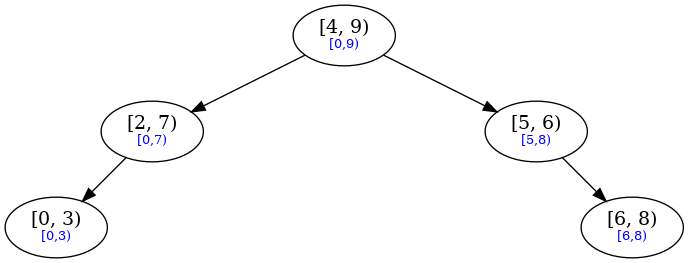

- Each node stores the interval it represents
  - AND it stores the maximum range of the sub-tree it represents
- The nodes are sorted by starting position, then ending position

  ```
  interval_1 < interval_2 =
      interval_1.start < interval_2.start ||
      (interval_1.start == interval_2.start && interval_1.end < interval_2.end)
  ```

Work with a partner:

Annotate each node with the maximum bounds of the respective subtree.

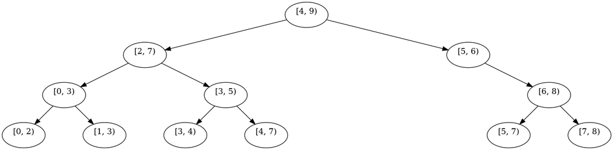

## Querying an Interval Tree

- Compare to the left maximum bounds
  - If they overlap the point, go left
- Compare to the current node
  - If the current interval overlaps the point, include it
- Compare to the right maximum bounds
  - If they overlap the point, go right
- What is the base case?
- Do we progress towards the base case?
- Is the induction correct?

What is the set of intervals that overlap 3?

- Does 3 overlap `[0, 7)`? Yes. Go left.
  - Does 3 overlap `[0, 3)`? No.
  - Does 3 overlap `[2, 7)`? Yes. Include **`[2, 7)`**.
  - Does 3 overlap `[3, 7)`? Yes. Go right.
    - Does 3 overlap `[3, 4)`? Yes. Go left.
      - Does 3 overlap `[3, 4)`? Yes. Include **`[3, 4)`**.
    - Does 3 overlap `[3, 5)`? Yes. Include **`[3, 5)`**.
    - Does 3 overlap `[4, 7)`? No.
- Does 3 overlap `[4, 9)`? No.
- Does 3 overlap `[5, 8)`? No.

**`[2, 7), [3, 4), [3, 5)`**

Work with a partner:

What is the set of intervals that overlap 5?

```
void _query(int point, Node* node, vector<Interval>& results) {
    if (node->left is not null && node->min_max.contains(point)) { go left; }
    if (node->interval.contains(point) { results.push_back(node->interval); }
    // check right
}
```

- Does 5 overlap `[0, 7)`? Yes. Go left.
  - Does 5 overlap `[0, 3)`? No.
  - Does 5 overlap `[2, 7)`? Yes. Include **`[2, 7)`**.
  - Does 5 overlap `[3, 7)`? Yes. Go right.
    - Does 5 overlap `[3, 4)`? No.
    - Does 5 overlap `[3, 5)`? No.
    - Does 5 overlap `[4, 7)`? Yes. Go right.
      - Does 5 overlap `[4, 7)`? Yes. Include **`[4, 7)`**.
- Does 5 overlap `[4, 9)`? Yes. Include **`[4, 9)`**.
- Does 5 overlap `[5, 8)`? Yes. Go right.
  - Does 5 overlap `[5, 6)`? Yes. Include **`[5, 6)`**.
  - Does 5 overlap `[5, 8)`? Yes. Go right.
    - Does 5 overlap `[5, 7)`? Yes. Go left.
      - Does 5 overlap `[5, 7)`? Yes. Include **`[5, 7)`**.
    - Does 5 overlap `[6, 8)`? No.
    - Does 5 overlap `[7, 8)`? No.

**`[2, 7), [4, 7), [4, 9), [5, 6), [5, 7)`**

### Big-O Complexity of Query

What is the big-O complexity of the interval tree query?

- How much work do we do at each node?
  - Compare to interval and each child max interval: $O(1)$
- How many nodes do we visit?
- When none of the intervals overlap each other, how many nodes would we visit?
- When all of the intervals overlap the point, how many nodes should we visit?
- When many intervals overlap each other, what happens to the performance of the query?
- When none of the intervals overlap each other, how many nodes would we visit?
  - $O(\log n)$
- When all of the intervals overlap the point, how many nodes should we visit?
  - $O(n)$
  - Is this poor performance?
    - Not necessarily: if all the intervals overlap, then they should all be returned, which means visiting all of them.

What kinds of trees have poor query performance?

- Imbalanced trees
- Leaves with broad ranges
  - You have to search through many small, non-overlapping nodes in order to reach the broad, overlapping nodes.

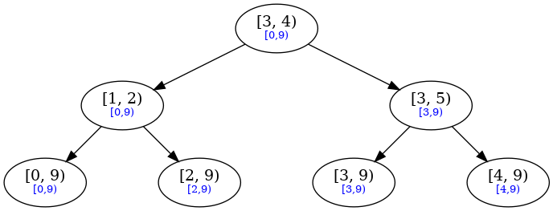

What intervals overlap 5?

**`[0, 9), [2, 9), [3, 9), [4, 9)`**

How many nodes got visited?

**All of them** $O(n)$

## Adding to an Interval Tree

Do a BST insert!

💪🏻

Ok, maybe it's a *little* more nuanced than that. 🙂

### Interval Tree Insert

- Using the BST insert algorithm, find where the new interval will go and insert it
  - Use the interval comparison operator defined earlier
- As you recurse out, if a node was added, update the max intervals.
  - Compare the node max intervals to the child max intervals

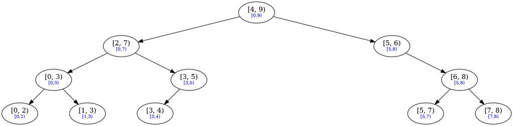

What happens when I add `[4, 7)`?

- `[4, 7) < [4, 9)` - go left
  - `[4, 7) > [2, 7)` - go right
    - `[4, 7) > [3, 5)` - go right
      - Add `[4, 7)` to the tree
    - Update max interval of `[3, 5)` to `[3, 7)`
  - Compare max interval of `[2, 7)` - no change needed.
- Compare max interval of `[4, 9)` - no change needed.

## Removing from an Interval Tree

- Using the BST remove algorithm, remove the interval (if present)
- As you recurse out, if a node was removed, update the max intervals

What happens when I remove `[2, 7)`?

- `[2,7) < [4,9)` - go left
  - `[2,7) == [2, 7)`, remove this node
    - Find the IOP => `[1, 3)`
    - Replace the value with IOP value
    - Remove IOP
      - `[1, 3) > [0, 3)` - go right
        - `[1, 3) == [1, 3)` - remove it
      - Update max interval
    - Update max interval
  - Update max interval
- Update max interval

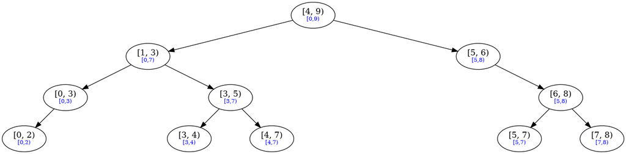

## Interval Trees: Key Ideas

- Interval trees allow you to quickly query for intervals that overlap a point
  - When the intervals are discrete, the performance is $O(\log n)$
  - When the intervals have lots of overlaps, the performance can approach $O(n)$
  - When all the intervals overlap the point, then you get $O(n)$ performance
    - But in this case this is as good as you could expect to do
- Augmented Interval Trees are modified BSTs that keep track of the minimum and maximum bounds of each subtree

## Review Lab Instructions

- `Interval` class
- `Node` class
- `Interval Tree` class
- Testing requirement
- Operator overloads
- How to set up the lab

https://github.com/BYUCS235/Interval-Tree-Lab